# PML Course Project

acabaya

8/15/2017

## Background

Using devices such as Jawbone Up, Nike FuelBand, and Fitbit it is now possible to collect a large amount of data about personal activity relatively inexpensively. These type of devices are part of the quantified self movement – a group of enthusiasts who take measurements about themselves regularly to improve their health, to find patterns in their behavior, or because they are tech geeks. One thing that people regularly do is quantify how much of a particular activity they do, but they rarely quantify how well they do it. In this project, your goal will be to use data from accelerometers on the belt, forearm, arm, and dumbell of 6 participants. They were asked to perform barbell lifts correctly and incorrectly in 5 different ways. More information is available from the website here: http://groupware.les.inf.puc-rio.br/har (see the section on the Weight Lifting Exercise Dataset).

## Data

The training data for this project are available here:

https://d396qusza40orc.cloudfront.net/predmachlearn/pml-training.csv

The test data are available here:

https://d396qusza40orc.cloudfront.net/predmachlearn/pml-testing.csv

The data for this project come from this source: http://groupware.les.inf.puc-rio.br/har. If you use the document you create for this class for any purpose please cite them as they have been very generous in allowing their data to be used for this kind of assignment.

## What you should submit

The goal of your project is to predict the manner in which they did the exercise. This is the “classe” variable in the training set. You may use any of the other variables to predict with. You should create a report describing how you built your model, how you used cross validation, what you think the expected out of sample error is, and why you made the choices you did. You will also use your prediction model to predict 20 different test cases.

## Initialize

Install the packages that will be used for this project:

```r
library(caret)
library(randomForest)
```

Load the data downloaded data set. Make sure it saved into the default working directory

```r
pmltraining <- read.table("./pml-training.csv", header=TRUE, sep=",")
pmltesting <- read.table("./pml-testing.csv", header=TRUE, sep=",")

dim(pmltraining)
```

```
## [1] 19622   160
```

```r
dim(pmltesting)
```

```
## [1]  20 160
```

## Cleaning the data sets

The training and testing data set have 160 variables! Most of these varables are either have NA values and/or are not relevanat to the study.

### Training Data Set:

```r
pmltrainig2 <- pmltraining[ , grepl("^roll",names(pmltraining))]
pmltrainig2 <- cbind(pmltrainig2, pmltraining[ , grepl("^pitch",names(pmltraining))])
pmltrainig2 <- cbind(pmltrainig2, pmltraining[, grepl("^yaw",names(pmltraining))])
pmltrainig2 <- cbind(pmltrainig2, pmltraining[, grepl("^accel",names(pmltraining))])

pmltrainig2 <- cbind(pmltrainig2, pmltraining[, grepl("^magnet",names(pmltraining))])
pmltrainig2 <- cbind(pmltrainig2, pmltraining[, grepl("^gyro",names(pmltraining))])
pmltrainig2 <- cbind(pmltrainig2, pmltraining[, grepl("^total",names(pmltraining))])
pmltrainig2 <- cbind(pmltrainig2, pmltraining[, "classe"])

colnames(pmltrainig2)[53] <- "classe"
dim(pmltrainig2)
```

```
## [1] 19622    53
```

### Testing Data Set:

```r
pmltesting2 <- pmltesting[ , grepl("^roll",names(pmltesting))]
pmltesting2 <- cbind(pmltesting2, pmltesting[ , grepl("^pitch",names(pmltesting))])
pmltesting2 <- cbind(pmltesting2, pmltesting[, grepl("^yaw",names(pmltesting))])
pmltesting2 <- cbind(pmltesting2, pmltesting[ , grepl("^accel",names(pmltesting))])

pmltesting2 <- cbind(pmltesting2, pmltesting[, grepl("^magnet",names(pmltesting))])
pmltesting2 <- cbind(pmltesting2, pmltesting[, grepl("^gyro",names(pmltesting))])
pmltesting2 <- cbind(pmltesting2, pmltesting[, grepl("^total",names(pmltesting))])
pmltesting2 <- cbind(pmltesting2, pmltesting[, "problem_id"])

colnames(pmltesting2)[53] <- "problem_id"
dim(pmltesting2)
```

```
## [1] 20 53
```

Both Training and Tesitng Data are not reduced to 53 variables.

Perform further cleaning by removing other varaibles that are not numeric class.

```r
# identify variables that are numeric class
numCol <- which(lapply(pmltesting2, class) %in% "numeric")

# assign these varaibles to new trainingS and add classe column.
trainingS <- pmltrainig2[, numCol]
trainingS$classe <- pmltrainig2$classe

#perform the same to testing data set.
testing <- pmltesting2[, numCol]
```

## Data Splitting the Training Data Set

Since the training data set have 19,622 we will split the dataset into 2 subsets: training and xvalidation. We will build our model on the training and use the xvalidation for cross validation later.

Since the data set is large enough, lets split by 75:25.

```r
set.seed(1000000)
inTrain<- createDataPartition(trainingS$classe, p=0.75, list=FALSE)

training <- trainingS[inTrain, ]
xvalidation <- trainingS[-inTrain, ]
```

```r
dim(training)
```

```
## [1] 14718    25
```

```r
dim(xvalidation)
```

```
## [1] 4904   25
```

## The Train Model Using Random Forrest

A random forest model was tested to see if that method fit the data appropriately.

```r
modFit <- train(classe ~., method="rf", data=training,
                  trControl=trainControl(method='cv'),
                  number=5, allowParallel=TRUE, importance=TRUE )
modFit
```

```
## Random Forest
##
## 14718 samples
##    24 predictor
##     5 classes: 'A', 'B', 'C', 'D', 'E'
##
## No pre-processing
## Resampling: Cross-Validated (10 fold)
## Summary of sample sizes: 13246, 13246, 13246, 13245, 13247, 13246, ...
## Resampling results across tuning parameters:
##
##   mtry  Accuracy   Kappa
##    2    0.9916427  0.9894285
##   13    0.9908270  0.9883986
##   24    0.9873620  0.9840177
##
## Accuracy was used to select the optimal model using  the largest value.
## The final value used for the model was mtry = 2.
```

We derive a high degree of model fit acuracy using the 24 variables.

## Calculate and Plot Variable Importance

We can determine the level of importance of each varable from the following lines:

```r
varImp(modFit)
```

```
## rf variable importance
##
##   variables are sorted by maximum importance across the classes
##   only 20 most important variables shown (out of 24)
##
##                       A      B     C     D      E
## pitch_belt       62.568 100.00 72.86 72.67 66.298
## yaw_belt         79.836  72.99 54.04 91.36 31.673
## roll_belt        53.822  86.51 77.10 69.75 78.720
## pitch_forearm    36.157  49.02 41.54 83.95 45.851
## roll_dumbbell    35.437  43.65 74.74 49.84 35.103
## roll_arm         23.396  59.65 45.54 59.63 30.265
## gyros_dumbbell_y 42.879  49.98 52.29 40.81 27.851
## roll_forearm     28.371  25.18 51.60 42.12 27.520
## yaw_arm          33.616  50.04 41.54 43.47 23.665
## yaw_dumbbell     20.132  30.11 45.93 36.67 38.947
## gyros_belt_z     27.355  39.46 29.32 45.23 42.114
## yaw_forearm      24.826  44.52 34.64 41.03 41.680
## gyros_dumbbell_x 13.117  44.39 33.15 35.35 27.702
## gyros_arm_y      17.283  40.76 25.23 33.75 22.063
## pitch_dumbbell    7.519  29.79 40.06 17.43 16.582
## gyros_forearm_z   9.753  38.21 24.28 22.78 21.586
## gyros_forearm_y   9.827  33.64 21.76 22.26  8.885
## gyros_arm_x      10.791  31.70 19.08 25.92 21.718
## gyros_belt_x     22.542  30.22 27.01 24.56 18.799
## pitch_arm         7.860  29.34 27.17 28.46 22.957
```

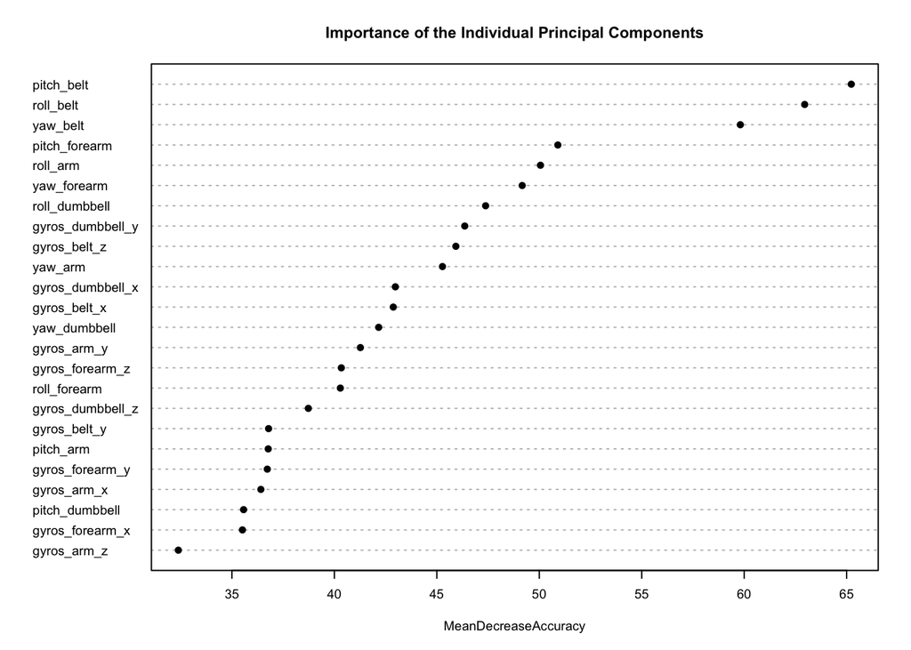

```r
varImpPlot(modFit$finalModel, sort = TRUE, type = 1, pch = 19, col = 1, cex = 0.6,
           main = "Importance of the Individual Principal Components")
```

## In Sample & Out of Sample Error

Perform the in-sample error to get the error rate using the the same data used to build the predictor.

```r
inSample = predict(modFit, training)
confusionMatrix(training$classe, inSample)
```

```
## Confusion Matrix and Statistics
##
##           Reference
## Prediction    A    B    C    D    E
##          A 4185    0    0    0    0
##          B    0 2848    0    0    0
##          C    0    0 2567    0    0
##          D    0    0    0 2412    0
##          E    0    0    0    0 2706
##
## Overall Statistics
##
##                Accuracy : 1
##                  95% CI : (0.9997, 1)
##     No Information Rate : 0.2843
##     P-Value [Acc > NIR] : < 2.2e-16
##
##                   Kappa : 1
##  Mcnemar's Test P-Value : NA
##
## Statistics by Class:
##
##                      Class: A Class: B Class: C Class: D Class: E
## Sensitivity            1.0000   1.0000   1.0000   1.0000   1.0000
## Specificity            1.0000   1.0000   1.0000   1.0000   1.0000
## Pos Pred Value         1.0000   1.0000   1.0000   1.0000   1.0000
## Neg Pred Value         1.0000   1.0000   1.0000   1.0000   1.0000
## Prevalence             0.2843   0.1935   0.1744   0.1639   0.1839
## Detection Rate         0.2843   0.1935   0.1744   0.1639   0.1839
## Detection Prevalence   0.2843   0.1935   0.1744   0.1639   0.1839
## Balanced Accuracy      1.0000   1.0000   1.0000   1.0000   1.0000
```

Since we have a high accuracy based on the in-sample test, we can now cross validate it with the xvalidation dataset we have set aside and determine the accuracy of the train model we have.

```r
outSample = predict(modFit, xvalidation)
confusionMatrix(xvalidation$classe, outSample)
```

```
## Confusion Matrix and Statistics
##
##           Reference
## Prediction    A    B    C    D    E
##          A 1391    3    0    0    1
##          B    2  945    2    0    0
##          C    0    3  847    5    0
##          D    0    0   10  793    1
##          E    0    2    3    2  894
##
## Overall Statistics
##
##                Accuracy : 0.9931
##                  95% CI : (0.9903, 0.9952)
##     No Information Rate : 0.2841
##     P-Value [Acc > NIR] : < 2.2e-16
##
##                   Kappa : 0.9912
##  Mcnemar's Test P-Value : NA
##
## Statistics by Class:
##
##                      Class: A Class: B Class: C Class: D Class: E
## Sensitivity            0.9986   0.9916   0.9826   0.9912   0.9978
## Specificity            0.9989   0.9990   0.9980   0.9973   0.9983
## Pos Pred Value         0.9971   0.9958   0.9906   0.9863   0.9922
## Neg Pred Value         0.9994   0.9980   0.9963   0.9983   0.9995
## Prevalence             0.2841   0.1943   0.1758   0.1631   0.1827
## Detection Rate         0.2836   0.1927   0.1727   0.1617   0.1823
## Detection Prevalence   0.2845   0.1935   0.1743   0.1639   0.1837
## Balanced Accuracy      0.9987   0.9953   0.9903   0.9943   0.9980
```

## Predicting Classe of Testing Data Set

Utilize the prediction model on the testing data set.

```r
answer <- predict(modFit, newdata=testing)
answer
```

```
##  [1] B A B A A E D B A A B C B A E E A B B B
## Levels: A B C D E
```

Given of the high degree of accuracy using the xvalidatation subset, we can also say with a high degree of confidence that the answers we got when we applide the prediction model on the testing data set.

## Conclusion

Random Forrest provides a high degree of accuracy given the data set we have. The high level of accuracy was mainly due to the fact that we have a fairly large training data set to work with. We could also note that the method we used, though it gave a high level of accuracy, the modelling took considerable amount of time to calculate.